# Fig.1 Panel C — does gene expression differ between conditions?

Question: do YPD, fluconazole and synthetic complete 2% glucose (sc2glu) induce different gene expression programs, i.e. do the conditions separate samples in a low-dimensional (PCA) space?

Each point is one strain’s pseudobulk expression profile in one dataset (strain x dataset). If conditions drive distinct programs, points should cluster by condition; if replicates are reproducible, replicate 1 and replicate 2 of the same condition should overlap.

Six datasets, each its own 10x run:

- YPD.1, YPD.2: true replicates.
- sc2glu.1, sc2glu.2: true replicates. sc2glu.1 is small (~1,700 cells after doublet removal), so it is the noisiest dataset.
- Flu.1 (16 ug/ml fluconazole) and Flu.2 (8 ug/ml): **not** replicates. They are two doses, each a single run, so they are treated as two separate conditions (Fluconazole_16, Fluconazole_8). Dose and batch are confounded between them.

Three analyses:

1. Replicate 1: YPD.1 + sc2glu.1, plus both fluconazole doses (Flu.1, Flu.2)
2. Replicate 2: YPD.2 + sc2glu.2, plus both fluconazole doses (Flu.1, Flu.2)
3. All datasets: all six, four conditions (YPD, Fluconazole_16, Fluconazole_8, sc2glu). Do the YPD and sc2glu replicates overlap, and do the two fluconazole doses separate?

The fluconazole datasets have no replicate, so the same Flu.1 and Flu.2 samples appear in analyses 1 and 2; only the YPD and sc2glu replicate changes. They are drawn with their own point shape (“No replicate”).

Input: pseudobulk matrices before the “reliable transcripts” filter (`pseudobulk_<dataset>_without_filtering_transcripts.txt`), so every dataset is processed the same way and genes such as ERG11 are kept.

Method: raw pseudobulk counts are combined on shared genes and shared strains, lowly expressed genes are removed (>= 10 counts in >= 25% of samples), counts are variance-stabilized with DESeq2 `vst(blind = TRUE)` (the design is not used, so condition labels do not influence the transform), and PCA is run on the top 500 most variable genes. Separation is quantified with PERMANOVA (`vegan::adonis2`, Euclidean distance on the same 500 genes) and mean silhouette width by condition on PC1–PC10.

Caveat: every dataset is a separate 10x run, so condition is confounded with batch. The YPD and sc2glu replicates show how big batch effects alone are: condition separation only means something if it is much larger than replicate separation. There is no fluconazole replicate, so for fluconazole this check is not available.

Differential expression between the conditions is in `Fig1-PanelC-DE-between-conditions-unfiltered-transcripts.Rmd`.

```r
library(tidyverse)        # data wrangling (dplyr, tidyr, purrr) and plotting (ggplot2)
library(DESeq2)           # size-factor normalization and variance-stabilizing transform
library(patchwork)        # combine several ggplots into one figure
library(cluster)          # silhouette width
library(vegan)            # PERMANOVA (adonis2)
library(ggrepel)          # gene labels that do not overlap
library(clusterProfiler)  # GO enrichment
library(org.Sc.sgd.db)    # yeast gene annotation (ORF <-> gene name, GO terms)
# AnnotationDbi (loaded with org.Sc.sgd.db) masks dplyr's select/filter;
# force the dplyr versions so the tidyverse code below works
select <- dplyr::select
filter <- dplyr::filter  # often masked too
```

# Configuration

```r
# Root folder that holds one sub-folder per dataset
BASE <- "/projects/rps/cgsb/gresham/Akriti/wildyeast1/common_analysis_for_all"

# Pseudobulk count matrix for each dataset (genes x strains, counts summed
# over all cells of a strain). Names of this list are used as dataset labels.
PATHS <- list(
  YPD.1    = file.path(BASE, "YPD.1/fastlmm/data/pheno_data/pseudobulk_YPD.1_without_filtering_transcripts.txt"),
  YPD.2    = file.path(BASE, "YPD.2/fastlmm/data/pheno_data/pseudobulk_YPD.2_without_filtering_transcripts.txt"),
  Flu.1    = file.path(BASE, "Flu.1/fastlmm/data/pheno_data/pseudobulk_flu.1_without_filtering_transcripts.txt"),
  Flu.2    = file.path(BASE, "Flu.2/fastlmm/data/pheno_data/pseudobulk_flu.2_without_filtering_transcripts.txt"),
  sc2glu.1 = file.path(BASE, "sc2glu.1/fastlmm/data/pheno_data/pseudobulk_sc2glu.1_only_without_filtering_transcripts.txt"),
  sc2glu.2 = file.path(BASE, "sc2glu.2/fastlmm/data/pheno_data/pseudobulk_sc2glu.2_only_without_filtering_transcripts.txt")
)

# Table mapping common gene names (gene_name) to ORF IDs (gene_id)
ANNOT <- "/scratch/aa9679/SingleCell_cerevisiae/Gene_exp_analysis/yeast_custom_annotations.csv"

# Analysis parameters
MIN_COUNT   <- 10    # expression filter: >= MIN_COUNT counts ...
MIN_FRAC    <- 0.25  # ... in >= MIN_FRAC of the samples in the analysis
N_TOP_GENES <- 500   # most variable genes used for PCA / PERMANOVA
N_PCS_SIL   <- 10    # PCs used for silhouette width

# All figures and tables are written here (created if missing)
OUT_DIR <- "../results"
dir.create(OUT_DIR, showWarnings = FALSE, recursive = TRUE)
```

# Load

```r
# Read one tab-separated pseudobulk file: first column = gene IDs (row names),
# header = strain names. check.names = FALSE keeps strain names exactly as
# written (R would otherwise replace characters such as "-").
read_pseudobulk <- function(path, sep = "\t") {
  if (!file.exists(path)) {
    stop("File not found: ", path, "\n  (getwd(): ", getwd(), ")")
  }
  read.csv(path, sep = sep, row.names = 1, header = TRUE, check.names = FALSE)
}

# Read all six datasets into a named list: raw$YPD.1, raw$Flu.2, ...
raw <- lapply(PATHS, read_pseudobulk)

# Print the size of each matrix as a sanity check
for (nm in names(raw)) {
  cat(sprintf("%-9s %5d genes x %4d strains\n", nm, nrow(raw[[nm]]), ncol(raw[[nm]])))
}
```

```
## YPD.1      5745 genes x   82 strains
## YPD.2      5747 genes x   81 strains
## Flu.1      5671 genes x   74 strains
## Flu.2      5722 genes x   67 strains
## sc2glu.1   5748 genes x   66 strains
## sc2glu.2   5734 genes x   71 strains
```

All matrices mix ORF IDs and common gene names; convert everything to ORF IDs so genes match across datasets (same conversion as the Panel C/D Rmd).

```r
all_custom_gene_annotations <- read.csv(ANNOT, stringsAsFactors = FALSE)

# Named vector: names = common gene names, values = ORF IDs
# (e.g. common_to_orf["ERG11"] = "YHR007C")
common_to_orf <- all_custom_gene_annotations %>%
  filter(!is.na(gene_name), !is.na(gene_id)) %>%
  distinct(gene_name, gene_id) %>%
  deframe()

# Rename the rows of one matrix to ORF IDs
to_orf <- function(mat, label) {
  ids    <- rownames(mat)
  # Does the ID already look like a systematic ORF name (e.g. YHR007C, YLR154C-G)?
  is_orf <- grepl("^Y[A-Z]{2}\\d{3}[WC](-[A-Z])?$", ids)
  # Keep ORFs as is; translate common names; leave unknown names unchanged
  orf    <- ifelse(is_orf, ids,
                   ifelse(ids %in% names(common_to_orf), common_to_orf[ids], ids))
  # Two rows can end up with the same ORF (e.g. the gene was listed under both
  # its ORF and its common name); keep the first and drop the rest
  dup <- duplicated(orf)
  cat(sprintf("%-9s converted %4d names to ORFs | dropped %d duplicates\n",
              label, sum(!is_orf & orf != ids), sum(dup)))
  mat <- mat[!dup, , drop = FALSE]
  rownames(mat) <- orf[!dup]
  mat
}

# Apply to every dataset (imap passes the dataset name as `label`)
raw <- imap(raw, to_orf)
```

```
## YPD.1     converted 2084 names to ORFs | dropped 0 duplicates
## YPD.2     converted 2084 names to ORFs | dropped 0 duplicates
## Flu.1     converted 2074 names to ORFs | dropped 0 duplicates
## Flu.2     converted 2082 names to ORFs | dropped 0 duplicates
## sc2glu.1  converted 2084 names to ORFs | dropped 0 duplicates
## sc2glu.2  converted 2083 names to ORFs | dropped 0 duplicates
```

```r
# Stop if any matrix still has duplicate gene IDs
stopifnot(all(map_lgl(raw, ~ !any(duplicated(rownames(.x))))))
```

# Shared genes and strains

The same genes and strains are used in all three analyses, so the plots are directly comparable and differences are not driven by which strains overlap.

```r
# Genes / strains present in all six datasets
shared_genes   <- Reduce(intersect, lapply(raw, rownames))
shared_strains <- Reduce(intersect, lapply(raw, colnames))
cat("Genes shared across all datasets:  ", length(shared_genes),   "\n")
```

```
## Genes shared across all datasets:   5657
```

```r
cat("Strains shared across all datasets:", length(shared_strains), "\n")
```

```
## Strains shared across all datasets: 60
```

```r
# ORF -> common name for labelling
# (falls back to the ORF ID when the gene has no common name)
gene_label <- function(orfs) {
  nm <- suppressMessages(AnnotationDbi::mapIds(org.Sc.sgd.db, keys = orfs, keytype = "ORF",
                                                column = "GENENAME", multiVals = "first"))
  coalesce(unname(nm), orfs)
}
```

# PCA function

```r
# Condition and replicate of each dataset, joined onto the samples below.
# Flu.1 (16 ug/ml) and Flu.2 (8 ug/ml) are different doses, not replicates:
# each is its own condition with no replicate.
dataset_info <- tribble(
  ~dataset,   ~condition,       ~replicate,
  "YPD.1",    "YPD",            "Replicate 1",
  "YPD.2",    "YPD",            "Replicate 2",
  "Flu.1",    "Fluconazole_16", "No replicate",
  "Flu.2",    "Fluconazole_8",  "No replicate",
  "sc2glu.1", "sc2glu",         "Replicate 1",
  "sc2glu.2", "sc2glu",         "Replicate 2"
)
CONDITION_LEVELS <- c("YPD", "Fluconazole_16", "Fluconazole_8", "sc2glu")

# Run the full pipeline (combine -> filter -> normalize -> PCA -> statistics)
# on a set of datasets. `datasets` = names from PATHS, `label` = printed title.
# Returns a list with PC scores, % variance, summary stats and gene loadings.
# min_frac / n_top / n_pcs_sil default to the global parameters; they are only
# changed in the parameter-sensitivity section at the end.
condition_pca <- function(datasets, label, min_frac = MIN_FRAC,
                          n_top = N_TOP_GENES, n_pcs_sil = N_PCS_SIL) {
  cat("\n---", label, "---\n")

  # 1. Combine datasets side by side.
  # raw counts: genes x (strain | dataset)
  # Each column is one sample = one strain in one dataset, e.g. "strainA|YPD.1"
  counts <- do.call(cbind, lapply(datasets, function(ds) {
    m <- as.matrix(raw[[ds]][shared_genes, shared_strains])
    colnames(m) <- paste(shared_strains, ds, sep = "|")
    m
  }))
  # DESeq2 needs integer counts
  counts <- round(counts)
  # 2. Expression filter: keep genes with >= MIN_COUNT counts in at least
  # min_frac of the samples (removes genes that are mostly zero / noise)
  counts <- counts[rowSums(counts >= MIN_COUNT) >= min_frac * ncol(counts), , drop = FALSE]

  # 3. Sample table: split "strain|dataset" back into two columns and add
  # condition and replicate from dataset_info
  meta <- tibble(sample = colnames(counts)) %>%
    separate(sample, into = c("strain", "dataset"), sep = "\\|", remove = FALSE) %>%
    left_join(dataset_info, by = "dataset") %>%
    mutate(condition = factor(condition, levels = CONDITION_LEVELS),
           condition = droplevels(condition),
           replicate = factor(replicate),
           dataset   = factor(dataset, levels = datasets))

  # 4. Normalization. design = ~ 1 means no condition information is used:
  # the transform is unsupervised, so it cannot create condition separation.
  dds <- DESeqDataSetFromMatrix(
    countData = counts,
    colData   = data.frame(meta, row.names = meta$sample),
    design    = ~ 1
  )
  # Size factors correct for sequencing depth (number of cells x reads per
  # strain). The default method fails if every gene has a zero in some sample;
  # "poscounts" ignores zeros and works in that case.
  dds <- tryCatch(
    estimateSizeFactors(dds),
    error = function(e) {
      message(label, ": standard size factors failed, using type = 'poscounts'")
      estimateSizeFactors(dds, type = "poscounts")
    }
  )
  # Variance-stabilizing transform: log2-like scale on which low- and
  # high-expressed genes have similar variance, so PCA is not dominated by a
  # few very highly expressed genes. blind = TRUE ignores the design.
  vsd <- assay(vst(dds, blind = TRUE))

  # 5. PCA on the n_top genes that vary most across samples
  top_genes <- head(order(apply(vsd, 1, var), decreasing = TRUE), min(n_top, nrow(vsd)))
  x   <- t(vsd[top_genes, ])      # samples x genes
  # center = TRUE subtracts each gene's mean; scale. = FALSE keeps the vst
  # scale, so genes that vary more contribute more
  pca <- prcomp(x, center = TRUE, scale. = FALSE)
  # % of total variance explained by each PC (used in the axis labels)
  var_expl <- 100 * pca$sdev^2 / sum(pca$sdev^2)

  cat("Samples:", nrow(x), "| genes after expression filter:", nrow(counts),
      "| genes used for PCA:", ncol(x), "\n")
  cat(sprintf("PC1 = %.1f%%, PC2 = %.1f%% variance\n", var_expl[1], var_expl[2]))

  # 6. Statistics
  # how strongly does condition separate samples?
  # PERMANOVA: fraction of the between-sample distance explained by condition
  # (R2) and a permutation p-value (999 shuffles of the condition labels)
  perm <- adonis2(dist(x) ~ condition, data = meta, permutations = 999)
  # Silhouette width per sample (-1 to 1): how much closer a sample is to its
  # own condition than to the nearest other condition, on PC1 to PC<n_pcs_sil> (default 10).
  # Mean near 1 = tight separate clusters; near 0 = conditions overlap.
  sil  <- silhouette(as.integer(meta$condition),
                     dist(pca$x[, seq_len(min(n_pcs_sil, ncol(pca$x)))]))
  cat(sprintf("PERMANOVA (condition): R2 = %.3f, p = %.3g\n",
              perm$R2[1], perm$`Pr(>F)`[1]))
  cat(sprintf("Mean silhouette width (condition, PC1-%d): %.3f\n",
              n_pcs_sil, mean(sil[, "sil_width"])))

  # 7. Return everything the plots and later sections need
  list(
    # sample table + PC1-PC5 coordinates (one row per point on the PCA plot)
    scores   = bind_cols(meta, as_tibble(pca$x[, 1:5])),
    var_expl = var_expl,
    # one-row summary of this analysis
    stats    = tibble(analysis        = label,
                      n_samples       = nrow(x),
                      n_strains       = length(unique(meta$strain)),
                      n_genes         = ncol(x),
                      PC1_pct         = var_expl[1],
                      PC2_pct         = var_expl[2],
                      permanova_R2    = perm$R2[1],
                      permanova_p     = perm$`Pr(>F)`[1],
                      mean_silhouette = mean(sil[, "sil_width"])),
    loadings = pca$rotation[, 1:5],   # genes x PCs, for the PC-loading / GO check
    # transformed data and sample table, reused for the nested PERMANOVA
    x = x, meta = meta
  )
}
```

# Plot theme and function

```r
# Shared publication style: white background, no grid, Arial, black axes
pub_theme <- theme_classic(base_size = 15, base_family = "Arial") +
  theme(
    axis.title = element_text(size = 15, face = "bold", color = "black",
                              family = "Arial"),
    axis.text  = element_text(size = 15, color = "black", family = "Arial"),
    axis.line  = element_line(linewidth = 0.4, color = "black"),
    axis.ticks = element_line(linewidth = 0.35, color = "black"),
    panel.grid       = element_blank(),
    plot.background  = element_rect(fill = "white", color = NA),
    panel.background = element_rect(fill = "white", color = NA),
    legend.text      = element_text(size = 13),
    legend.title     = element_text(size = 13, face = "bold")
  )

# Color = condition, point shape = replicate
# (16 = filled circle, 2 = open triangle, 15 = filled square for the unreplicated Flu doses;
#  the open triangle lets overlapping replicate 1 points show through)
# (two shades for the fluconazole doses: dark red = 16 ug/ml, orange = 8 ug/ml)
condition_colors <- c(
  "YPD"            = "#4E79A7",
  "Fluconazole_16" = "#C0392B",
  "Fluconazole_8"  = "#F28E2B",
  "sc2glu"         = "#59A14F"
)
replicate_shapes <- c("Replicate 1" = 16, "Replicate 2" = 2, "No replicate" = 15)

# Save one plot to OUT_DIR as vector PDF (cairo keeps Arial embedded) and 300 dpi TIFF
save_plot <- function(p, name, width, height) {
  ggsave(file.path(OUT_DIR, paste0(name, ".pdf")), p,
         width = width, height = height, units = "in", device = cairo_pdf)
  ggsave(file.path(OUT_DIR, paste0(name, ".tiff")), p,
         width = width, height = height, units = "in", dpi = 300,
         device = "tiff", compression = "lzw")
}

# PC1 vs PC2 scatter for one condition_pca() result
plot_pca <- function(res, title) {
  s <- res$stats
  ggplot(res$scores, aes(x = PC1, y = PC2, color = condition, shape = replicate)) +
    # show.legend = TRUE: draw legend keys for every shape/color in the scale limits,
    # even ones absent from this panel, so all panels share one legend
    geom_point(alpha = 0.5, size = 1.6, stroke = 0.6, show.legend = TRUE) +
    # 95% normal-data ellipse around each condition's points
    stat_ellipse(aes(group = condition), linewidth = 0.5, show.legend = FALSE) +
    scale_color_manual(values = condition_colors) +
    # limits = both replicates, so the legend is identical across panels
    scale_shape_manual(values = replicate_shapes, limits = names(replicate_shapes)) +
    # shape keys in neutral grey (color is shown by the Condition legend)
    guides(shape = guide_legend(override.aes = list(color = "grey30", alpha = 1))) +
    # PERMANOVA and silhouette results in the top-left corner
    annotate("text", x = -Inf, y = Inf,
             label = sprintf("PERMANOVA R^2 = %.2f, p = %.3g\nsilhouette = %.2f",
                             s$permanova_R2, s$permanova_p, s$mean_silhouette),
             hjust = -0.05, vjust = 1.2, size = 3.5) +
    labs(title = title,
         x = sprintf("PC1 (%.1f%%)", res$var_expl[1]),
         y = sprintf("PC2 (%.1f%%)", res$var_expl[2]),
         color = "Condition", shape = "Replicate") +
    pub_theme
}
```

# Analysis 1 — replicate 1: YPD.1, sc2glu.1 + both fluconazole doses

```r
# PCA on YPD.1, sc2glu.1, Flu.1 (16 ug/ml) and Flu.2 (8 ug/ml)
res_set1 <- condition_pca(c("YPD.1", "Flu.1", "Flu.2", "sc2glu.1"),
                          "Replicate 1: YPD.1 + Flu.1 + Flu.2 + sc2glu.1")
```

```
##
## --- Replicate 1: YPD.1 + Flu.1 + Flu.2 + sc2glu.1 ---
```

```
## Samples: 240 | genes after expression filter: 4426 | genes used for PCA: 500
## PC1 = 40.8%, PC2 = 8.7% variance
## PERMANOVA (condition): R2 = 0.370, p = 0.001
## Mean silhouette width (condition, PC1-10): 0.348
```

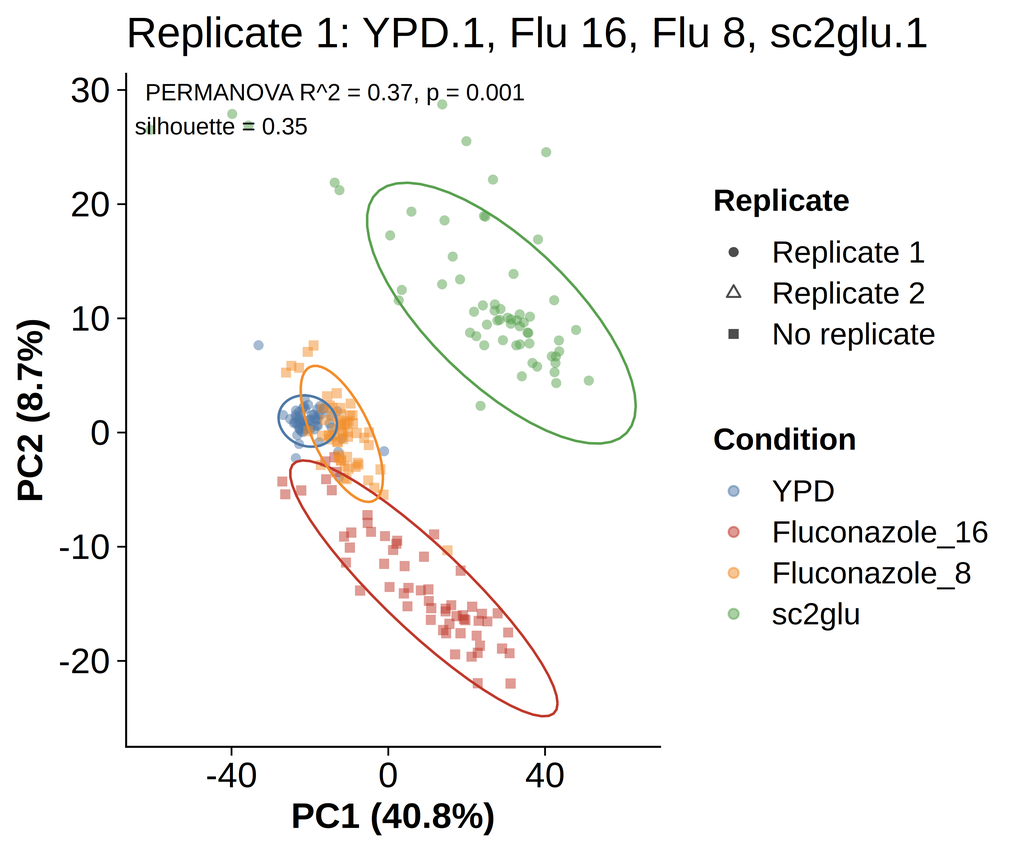

```r
p_set1   <- plot_pca(res_set1, "Replicate 1: YPD.1, Flu 16, Flu 8, sc2glu.1")
p_set1
```

# Analysis 2 — replicate 2: YPD.2, sc2glu.2 + both fluconazole doses

```r
# PCA on YPD.2, sc2glu.2, Flu.1 (16 ug/ml) and Flu.2 (8 ug/ml)
res_set2 <- condition_pca(c("YPD.2", "Flu.1", "Flu.2", "sc2glu.2"),
                          "Replicate 2: YPD.2 + Flu.1 + Flu.2 + sc2glu.2")
```

```
##
## --- Replicate 2: YPD.2 + Flu.1 + Flu.2 + sc2glu.2 ---
```

```
## -- note: fitType='parametric', but the dispersion trend was not well captured by the
##    function: y = a/x + b, and a local regression fit was automatically substituted.
##    specify fitType='local' or 'mean' to avoid this message next time.
```

```
## Samples: 240 | genes after expression filter: 4499 | genes used for PCA: 500
## PC1 = 43.0%, PC2 = 11.0% variance
## PERMANOVA (condition): R2 = 0.511, p = 0.001
## Mean silhouette width (condition, PC1-10): 0.392
```

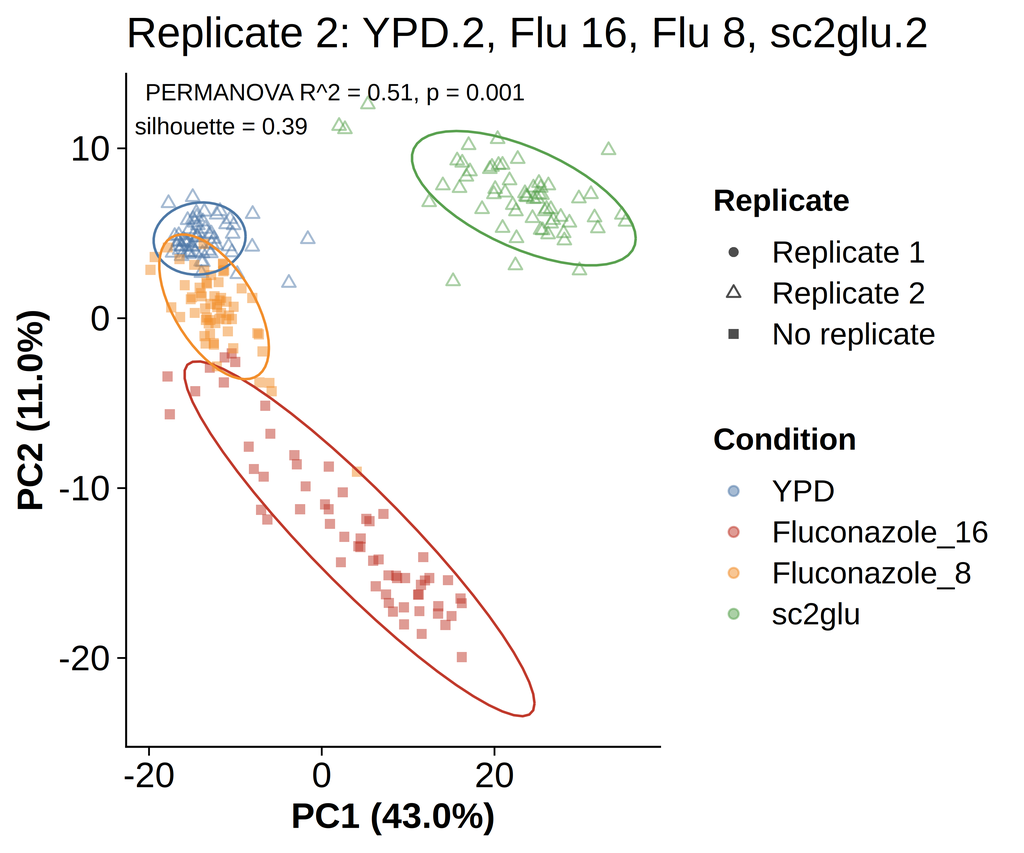

```r
p_set2   <- plot_pca(res_set2, "Replicate 2: YPD.2, Flu 16, Flu 8, sc2glu.2")
p_set2
```

# Analysis 3 — all datasets: do replicates overlap, do the doses separate?

All six datasets, four conditions. Replicates of YPD and of sc2glu should overlap (circles vs triangles of the same colour). The two fluconazole doses are separate conditions (dark red = 16 ug/ml, orange = 8 ug/ml); how far apart they sit reflects dose plus batch, which cannot be separated.

Beyond the plot, for each strain we compare the PCA distance between its two YPD (or sc2glu) replicates with its distance to another condition in the same run, and with its distance between the two fluconazole doses. A nested PERMANOVA splits the variance into condition and replicate-within-condition.

```r
# PCA on all six datasets together (four conditions)
res_all <- condition_pca(names(raw), "All: YPD.1 + YPD.2 + Flu.1 + Flu.2 + sc2glu.1 + sc2glu.2")
```

```
##
## --- All: YPD.1 + YPD.2 + Flu.1 + Flu.2 + sc2glu.1 + sc2glu.2 ---
```

```
## Samples: 360 | genes after expression filter: 4634 | genes used for PCA: 500
## PC1 = 48.5%, PC2 = 6.3% variance
## PERMANOVA (condition): R2 = 0.439, p = 0.001
## Mean silhouette width (condition, PC1-10): 0.337
```

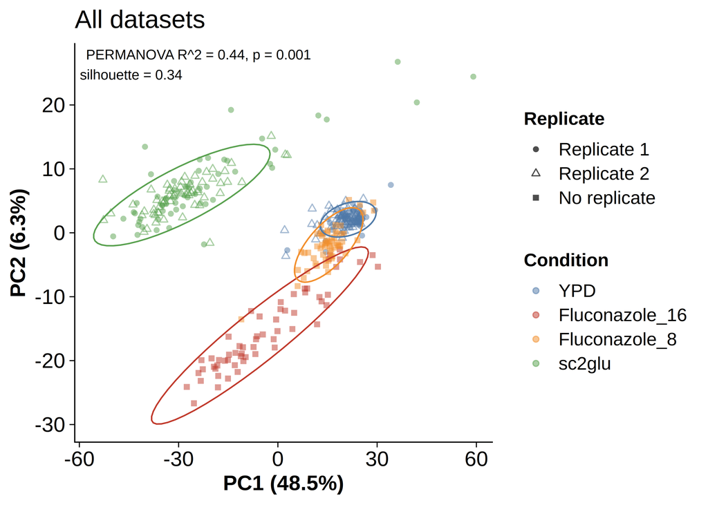

```r
p_all   <- plot_pca(res_all, "All datasets")
p_all
```

Points of different conditions overlap in the plot above, which hides whether the replicates agree. The same PCA (same coordinates) is split into one panel per condition below: each panel shows that condition’s samples coloured by replicate, on top of all other samples in grey.

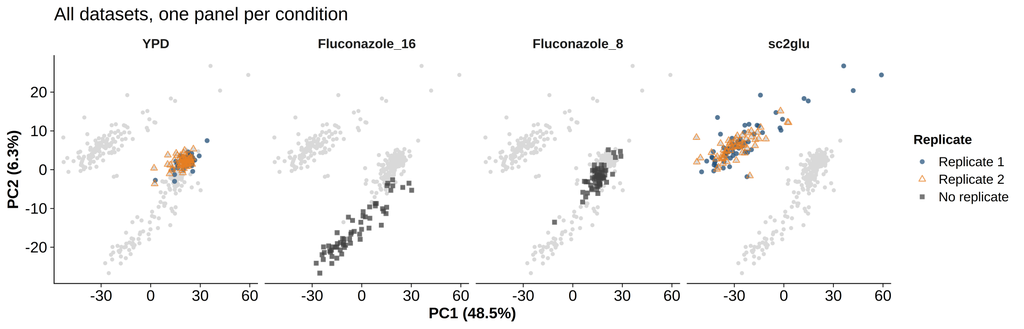

```r
replicate_colors <- c("Replicate 1" = "#1F4E79", "Replicate 2" = "#E67E22",
                      "No replicate" = "grey25")

plot_pca_by_condition <- function(res, title) {
  # all samples without the condition column, so they appear in every panel
  bg <- res$scores %>% select(-condition)
  ggplot(res$scores, aes(x = PC1, y = PC2)) +
    geom_point(data = bg, color = "grey85", size = 1) +
    geom_point(aes(color = replicate, shape = replicate), alpha = 0.7, size = 1.8,
               stroke = 0.7, show.legend = TRUE) +
    facet_wrap(~ condition, nrow = 1) +
    scale_color_manual(values = replicate_colors, limits = names(replicate_colors)) +
    scale_shape_manual(values = replicate_shapes, limits = names(replicate_shapes)) +
    labs(title = title,
         x = sprintf("PC1 (%.1f%%)", res$var_expl[1]),
         y = sprintf("PC2 (%.1f%%)", res$var_expl[2]),
         color = "Replicate", shape = "Replicate") +
    pub_theme +
    theme(strip.background = element_blank(),
          strip.text = element_text(size = 13, face = "bold"))
}

p_all_by_cond <- plot_pca_by_condition(res_all, "All datasets, one panel per condition")
p_all_by_cond
```

```r
# condition vs replicate-within-condition
# Nested PERMANOVA: R2 of "condition" = variance explained by the four
# conditions (the two Flu doses count as separate conditions);
# R2 of "condition:replicate" = variance explained by replicate (batch) within
# YPD and sc2glu (the Flu conditions have one replicate each, so they add
# nothing to this term). If condition R2 >> replicate R2, the condition effect
# is larger than the batch effect.
perm_nested <- adonis2(dist(res_all$x) ~ condition / replicate,
                       data = res_all$meta, permutations = 999, by = "terms")
perm_nested
```

```
## Permutation test for adonis under reduced model
## Terms added sequentially (first to last)
## Permutation: free
## Number of permutations: 999
##
## adonis2(formula = dist(res_all$x) ~ condition/replicate, data = res_all$meta, permutations = 999, by = "terms")
##                      Df SumOfSqs      R2       F Pr(>F)
## condition             3   181215 0.43923 96.4639  0.001 ***
## condition:replicate   2     9691 0.02349  7.7383  0.001 ***
## Residual            354   221672 0.53728
## Total               359   412577 1.00000
## ---
## Signif. codes:  0 '***' 0.001 '**' 0.01 '*' 0.05 '.' 0.1 ' ' 1
```

```r
# per-strain distances in PC1-PC2 space
# Reshape to one row per strain with columns PC1_YPD.1, PC2_YPD.1, PC1_Flu.1, ...
pc_wide <- res_all$scores %>%
  select(strain, dataset, PC1, PC2) %>%
  pivot_wider(names_from = dataset, values_from = c(PC1, PC2))

# Euclidean distance in PC1-PC2 between the same strain in dataset a and dataset b
# (returns one value per strain)
pc_dist <- function(a, b) {
  sqrt((pc_wide[[paste0("PC1_", a)]] - pc_wide[[paste0("PC1_", b)]])^2 +
       (pc_wide[[paste0("PC2_", a)]] - pc_wide[[paste0("PC2_", b)]])^2)
}

# Comparisons to make:
#   "same condition"  = replicate 1 vs replicate 2 of YPD or sc2glu (batch effect only)
#   "Flu dose"        = Flu.1 (16 ug/ml) vs Flu.2 (8 ug/ml) (dose + batch, not a replicate pair)
#   "diff. condition" = two conditions within one run (condition effect)
dist_pairs <- tribble(
  ~a,         ~b,         ~kind,
  "YPD.1",    "YPD.2",    "same condition",
  "sc2glu.1", "sc2glu.2", "same condition",
  "Flu.1",    "Flu.2",    "Flu dose",
  "YPD.1",    "Flu.1",    "diff. condition",
  "YPD.2",    "Flu.2",    "diff. condition",
  "YPD.1",    "sc2glu.1", "diff. condition",
  "YPD.2",    "sc2glu.2", "diff. condition"
)

# Compute the per-strain distances for every comparison (long table:
# one row per strain per comparison)
strain_dists <- pmap_dfr(dist_pairs, function(a, b, kind) {
  tibble(comparison = sprintf("%s vs %s\n(%s)", a, b, kind), kind = kind, dist = pc_dist(a, b))
}) %>%
  # keep the comparisons in the order of dist_pairs on the x axis
  mutate(comparison = fct_inorder(comparison))

# Median distance per comparison
knitr::kable(
  strain_dists %>% group_by(comparison) %>%
    summarise(n_strains = n(), median_dist = median(dist), .groups = "drop"),
  digits = 2, caption = "Per-strain distance in PC1-PC2 space"
)
```

Per-strain distance in PC1-PC2 space

| comparison | n_strains | median_dist |
| --- | --- | --- |
| YPD.1 vs YPD.2 |  |  |
| (same condition) | 60 | 2.18 |
| sc2glu.1 vs sc2glu.2 |  |  |
| (same condition) | 60 | 5.62 |
| Flu.1 vs Flu.2 |  |  |
| (Flu dose) | 60 | 27.69 |
| YPD.1 vs Flu.1 |  |  |
| (diff. condition) | 60 | 32.79 |
| YPD.2 vs Flu.2 |  |  |
| (diff. condition) | 60 | 8.09 |
| YPD.1 vs sc2glu.1 |  |  |
| (diff. condition) | 60 | 51.74 |
| YPD.2 vs sc2glu.2 |  |  |
| (diff. condition) | 60 | 51.48 |

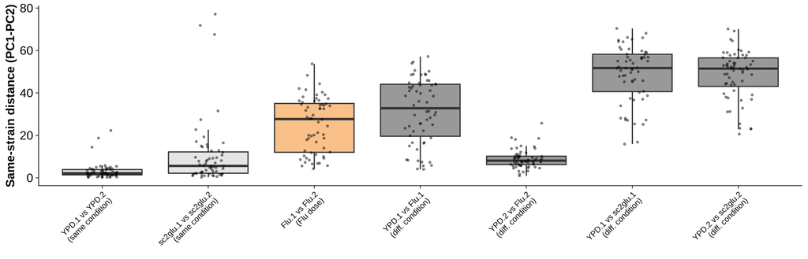

```r
# Boxplot of the distances (each dot = one strain); light grey = same
# condition, orange = Flu 16 vs 8 ug/ml, dark grey = different condition
p_dist <- ggplot(strain_dists, aes(x = comparison, y = dist, fill = kind)) +
  geom_boxplot(outlier.shape = NA) +
  geom_jitter(width = 0.15, alpha = 0.4, size = 0.8) +
  scale_fill_manual(values = c("same condition" = "grey90", "Flu dose" = "#F9C08A",
                               "diff. condition" = "grey60"),
                    guide = "none") +
  labs(x = NULL, y = "Same-strain distance (PC1-PC2)") +
  pub_theme +
  theme(axis.text.x = element_text(size = 10, angle = 45, hjust = 1))
p_dist
```

# Summary and save

```r
# One row of statistics per analysis
pca_stats <- bind_rows(res_set1$stats, res_set2$stats, res_all$stats)
knitr::kable(pca_stats, digits = 3, caption = "Condition separation per analysis")
```

Condition separation per analysis

| analysis | n_samples | n_strains | n_genes | PC1_pct | PC2_pct | permanova_R2 | permanova_p | mean_silhouette |
| --- | --- | --- | --- | --- | --- | --- | --- | --- |
| Replicate 1: YPD.1 + Flu.1 + Flu.2 + sc2glu.1 | 240 | 60 | 500 | 40.797 | 8.656 | 0.370 | 0.001 | 0.348 |
| Replicate 2: YPD.2 + Flu.1 + Flu.2 + sc2glu.2 | 240 | 60 | 500 | 42.979 | 10.973 | 0.511 | 0.001 | 0.392 |
| All: YPD.1 + YPD.2 + Flu.1 + Flu.2 + sc2glu.1 + sc2glu.2 | 360 | 60 | 500 | 48.463 | 6.307 | 0.439 | 0.001 | 0.337 |

```r
# Combined figure: top row = replicate 1 | replicate 2, bottom row = all datasets | distance boxplot
# (all PCA panels use the same color and shape scales, so their legends are merged into one)
fig_pca <- (p_set1 | p_set2) /
  (p_all | p_dist) + plot_layout(guides = "collect")
fig_pca
```

[figure not shown]

```r
# Save the combined figure
save_plot(fig_pca, "Fig1C_condition_PCA", width = 14, height = 11)

# Save each panel on its own
save_plot(p_set1, "Fig1C_PCA_replicate1",          width = 7, height = 5.5)
save_plot(p_set2, "Fig1C_PCA_replicate2",          width = 7, height = 5.5)
save_plot(p_all,  "Fig1C_PCA_all_datasets",        width = 7, height = 5.5)
save_plot(p_all_by_cond, "Fig1C_PCA_all_datasets_by_condition", width = 14, height = 4.5)
save_plot(p_dist, "Fig1C_per_strain_PC_distances", width = 7, height = 5.5)

write.csv(pca_stats, file.path(OUT_DIR, "Fig1C_condition_PCA_summary_stats.csv"),
          row.names = FALSE)
```

# Ergosterol gene set

Genes annotated to GO:0006696 “ergosterol biosynthetic process” (including child terms) in SGD; highlighted in the batch check below.

```r
# GOALL = genes annotated to the term or any of its child terms
erg_set <- AnnotationDbi::select(org.Sc.sgd.db, keys = "GO:0006696", keytype = "GOALL",
                                 columns = c("ORF", "GENENAME")) %>%
  filter(!is.na(ORF)) %>%
  # one row per gene (a gene can be returned once per evidence code)
  distinct(orf = ORF, gene_name = GENENAME) %>%
  # use the ORF ID as the name for genes without a common name
  mutate(gene_name = coalesce(gene_name, orf)) %>%
  arrange(gene_name)
# How many ergosterol genes survived into the shared gene set, and which are missing
cat("Ergosterol genes (GO:0006696):", nrow(erg_set),
    "| in shared gene set:", sum(erg_set$orf %in% shared_genes), "\n")
```

```
## Ergosterol genes (GO:0006696): 35 | in shared gene set: 34
```

```r
cat("Missing from shared gene set:",
    paste(erg_set$gene_name[!erg_set$orf %in% shared_genes], collapse = ", "), "\n")
```

```
## Missing from shared gene set: YPL062W
```

# Batch reproducibility of the condition effect

Condition and batch are confounded (each dataset is its own 10x run), but the replicates allow some checks:

- **sc2glu vs YPD**: a true replicate check. If the sc2glu effect is biological, sc2glu.1 - YPD.1 (run 1) should look like sc2glu.2 - YPD.2 (run 2). A batch artefact would not reproduce.
- **Fluconazole vs YPD**: Flu.1 - YPD.1 is the 16 ug/ml response (run 1) and Flu.2 - YPD.2 is the 8 ug/ml response (run 2). These are **not** replicates: a high correlation means a shared fluconazole response at both doses, and differences can come from dose or from batch.
- **Batch signature**: is the batch effect (YPD.2 - YPD.1) shared with sc2glu.2 - sc2glu.1, i.e. a systematic “run 2” signature? And how much of the Flu 8 - Flu 16 difference looks like that batch signature?

log2FC here is paired within strain (log2 normalized counts, test - ref) and averaged over the shared strains; genes with mean log2 expression <= 2 are dropped. The run 1 and run 2 estimates share no dataset, so their correlation is not inflated by shared noise.

```r
# Combine all six datasets (shared genes x shared strains); same column
# naming "strain|dataset" as in condition_pca(), but no expression filter here
counts_all <- round(do.call(cbind, lapply(names(raw), function(ds) {
  m <- as.matrix(raw[[ds]][shared_genes, shared_strains])
  colnames(m) <- paste(shared_strains, ds, sep = "|")
  m
})))
# DESeq2 object only for normalization (design = ~ 1, no model fitted)
dds_all <- DESeqDataSetFromMatrix(
  counts_all,
  data.frame(row.names = colnames(counts_all),
             dataset   = rep(names(raw), each = length(shared_strains))),
  design = ~ 1
)
# Depth-normalize, then log2(count + 1)
dds_all  <- estimateSizeFactors(dds_all, type = "poscounts")
log_norm <- log2(counts(dds_all, normalized = TRUE) + 1)
# Keep genes with mean log2 expression > 2 (fold changes of very low genes are noise)
expressed <- rownames(log_norm)[rowMeans(log_norm) > 2]
cat("Expressed genes used:", length(expressed), "\n")
```

```
## Expressed genes used: 4595
```

```r
# Per-gene log2 fold change of `test` over `ref`: compute test - ref for each
# strain separately (paired), then average over strains
paired_lfc <- function(test, ref) {
  rowMeans(log_norm[expressed, paste(shared_strains, test, sep = "|")] -
           log_norm[expressed, paste(shared_strains, ref,  sep = "|")])
}

# One row per gene, one column per comparison; flag ergosterol genes
batch_lfc <- tibble(
  gene      = expressed,
  flu16     = paired_lfc("Flu.1",    "YPD.1"),     # Flu 16 ug/ml effect (run 1)
  flu8      = paired_lfc("Flu.2",    "YPD.2"),     # Flu 8 ug/ml effect (run 2)
  sc_b1     = paired_lfc("sc2glu.1", "YPD.1"),     # sc2glu effect, run 1
  sc_b2     = paired_lfc("sc2glu.2", "YPD.2"),     # sc2glu effect, run 2
  batch_YPD = paired_lfc("YPD.2",    "YPD.1"),     # batch effects (true replicates)
  batch_sc  = paired_lfc("sc2glu.2", "sc2glu.1"),
  dose_Flu  = paired_lfc("Flu.2",    "Flu.1")      # 8 vs 16 ug/ml: dose + batch
) %>%
  left_join(erg_set %>% select(gene = orf, gene_name), by = "gene") %>%
  mutate(is_erg = !is.na(gene_name))

# Pearson and Spearman correlation across genes between two log2FC columns
cor_row <- function(test, a, b) {
  tibble(test = test,
         pearson_r  = cor(batch_lfc[[a]], batch_lfc[[b]]),
         spearman_r = cor(batch_lfc[[a]], batch_lfc[[b]], method = "spearman"))
}
# Row 1: high r = sc2glu effect reproduces across runs (true replicates).
# Row 2: high r = shared fluconazole response at 16 and 8 ug/ml (not a replicate test).
# Row 3: high r = a shared "run 2 vs run 1" batch signature.
# Row 4: high r = the Flu 8 vs 16 difference looks like that batch signature,
#        i.e. it is at least partly batch rather than dose.
batch_stats <- bind_rows(
  cor_row("sc2glu vs YPD: run 1 vs run 2 (replicates)",          "sc_b1",     "sc_b2"),
  cor_row("Flu vs YPD: 16 ug/ml (run 1) vs 8 ug/ml (run 2)",     "flu16",     "flu8"),
  cor_row("Batch effect: YPD.2 - YPD.1 vs sc2glu.2 - sc2glu.1",  "batch_YPD", "batch_sc"),
  cor_row("Batch YPD.2 - YPD.1 vs dose Flu.2 (8) - Flu.1 (16)",  "batch_YPD", "dose_Flu")
)
knitr::kable(batch_stats, digits = 3, caption = "Do condition effects reproduce across runs and doses?")
```

Do condition effects reproduce across runs and doses?

| test | pearson_r | spearman_r |
| --- | --- | --- |
| sc2glu vs YPD: run 1 vs run 2 (replicates) | 0.712 | 0.587 |
| Flu vs YPD: 16 ug/ml (run 1) vs 8 ug/ml (run 2) | 0.196 | 0.114 |
| Batch effect: YPD.2 - YPD.1 vs sc2glu.2 - sc2glu.1 | -0.265 | -0.295 |
| Batch YPD.2 - YPD.1 vs dose Flu.2 (8) - Flu.1 (16) | 0.091 | 0.114 |

```r
# Overall size of each effect: the spread (SD) of log2FC across genes.
# Compare condition effects (flu*, sc_*) with batch effects (batch_*) and the
# Flu dose difference (dose_Flu).
knitr::kable(
  batch_lfc %>% summarise(across(c(flu16, flu8, sc_b1, sc_b2, batch_YPD, batch_sc, dose_Flu), sd)),
  digits = 3, caption = "Size of each effect: SD of per-gene log2FC"
)
```

Size of each effect: SD of per-gene log2FC

| flu16 | flu8 | sc_b1 | sc_b2 | batch_YPD | batch_sc | dose_Flu |
| --- | --- | --- | --- | --- | --- | --- |
| 0.732 | 0.469 | 0.938 | 0.927 | 0.505 | 0.38 | 0.652 |

```r
# Ergosterol genes (expected fluconazole targets): do they go up at both doses?
knitr::kable(
  batch_lfc %>% filter(is_erg) %>%
    select(gene, gene_name, flu16, flu8, dose_Flu, batch_YPD) %>%
    arrange(desc(flu16)),
  digits = 2, caption = "Ergosterol genes: Flu vs YPD log2FC per dose, dose difference and YPD batch effect"
)
```

Ergosterol genes: Flu vs YPD log2FC per dose, dose difference and YPD batch effect

| gene | gene_name | flu16 | flu8 | dose_Flu | batch_YPD |
| --- | --- | --- | --- | --- | --- |
| YLR056W | ERG3 | 2.14 | 0.80 | -1.13 | 0.21 |
| YGR175C | ERG1 | 2.09 | 0.86 | -0.56 | 0.67 |
| YGR060W | ERG25 | 2.06 | 0.74 | -0.64 | 0.68 |
| YKL150W | MCR1 | 2.01 | 0.47 | -1.03 | 0.51 |
| YMR015C | ERG5 | 1.83 | 0.58 | -0.75 | 0.49 |
| YMR202W | ERG2 | 1.64 | 0.50 | -1.10 | 0.05 |
| YML126C | ERG13 | 1.57 | -0.52 | -0.71 | 1.38 |
| YER044C | ERG28 | 1.49 | 1.06 | -0.82 | -0.40 |
| YNL280C | ERG24 | 1.47 | 0.44 | -1.00 | 0.03 |
| YGL012W | ERG4 | 1.44 | 0.09 | -0.99 | 0.36 |
| YHR007C | ERG11 | 1.38 | 0.87 | -0.13 | 0.38 |
| YML008C | ERG6 | 1.35 | 0.05 | -1.09 | 0.21 |
| YPL170W | DAP1 | 1.19 | -0.07 | -1.59 | -0.33 |
| YHR042W | NCP1 | 1.16 | 0.49 | -0.16 | 0.51 |
| YGL001C | ERG26 | 1.08 | 0.16 | -1.01 | -0.09 |
| YLR100W | ERG27 | 1.03 | -0.14 | -1.71 | -0.55 |
| YMR134W | ERG29 | 0.79 | 0.22 | -1.12 | -0.55 |
| YHR072W | ERG7 | 0.73 | 0.14 | -0.20 | 0.39 |
| YMR208W | ERG12 | 0.70 | -0.16 | -1.00 | -0.13 |
| YPL028W | ERG10 | 0.49 | -0.44 | -0.92 | 0.01 |
| YHR190W | ERG9 | 0.40 | -0.03 | -0.85 | -0.43 |
| YML075C | HMG1 | 0.32 | 0.18 | 0.45 | 0.60 |
| YJL167W | ERG20 | 0.31 | -0.08 | -0.76 | -0.38 |
| YMR220W | ERG8 | 0.29 | -0.35 | -0.70 | -0.07 |
| YNR043W | MVD1 | 0.26 | -0.03 | -0.39 | -0.10 |
| YER125W | RSP5 | 0.17 | 0.07 | 0.22 | 0.32 |
| YLR228C | ECM22 | -0.24 | -0.24 | 0.66 | 0.66 |
| YLR450W | HMG2 | -0.26 | -0.18 | 0.53 | 0.44 |
| YPL117C | IDI1 | -0.41 | -0.27 | -0.12 | -0.26 |
| YML125C | PGA3 | -0.66 | 0.02 | 0.20 | -0.48 |
| YMR070W | MOT3 | -0.85 | -0.38 | 0.36 | -0.11 |

```r
# Scatter of one log2FC column against another (each dot = one gene);
# ergosterol genes in red and labelled, Pearson r in the corner
batch_scatter <- function(xcol, ycol, xlab, ylab) {
  r <- cor(batch_lfc[[xcol]], batch_lfc[[ycol]])
  ggplot(batch_lfc, aes(.data[[xcol]], .data[[ycol]])) +
    geom_hline(yintercept = 0, linewidth = 0.3, color = "grey50") +
    geom_vline(xintercept = 0, linewidth = 0.3, color = "grey50") +
    # other genes first (grey, underneath), then ergosterol genes on top
    geom_point(data = ~ filter(.x, !is_erg), size = 0.5, alpha = 0.3, color = "grey40", shape = 16) +
    geom_point(data = ~ filter(.x, is_erg), size = 1.8, color = "#E15759") +
    geom_text_repel(data = ~ filter(.x, is_erg), aes(label = gene_name),
                    size = 3, color = "#E15759", max.overlaps = 30) +
    annotate("text", x = -Inf, y = Inf, label = sprintf("Pearson r = %.2f", r),
             hjust = -0.1, vjust = 1.5, size = 4, fontface = "bold") +
    # same scale on x and y, so the diagonal is a true 1:1 line
    coord_fixed() +
    labs(x = xlab, y = ylab) +
    pub_theme +
    theme(axis.title = element_text(size = 12), axis.text = element_text(size = 11))
}

# Three panels: sc2glu effect run 1 vs run 2 | Flu effect 16 vs 8 ug/ml |
# batch effect YPD vs batch effect sc2glu
p_batch_sc   <- batch_scatter("sc_b1", "sc_b2",
                              "log2FC sc2glu.1 / YPD.1 (run 1)", "log2FC sc2glu.2 / YPD.2 (run 2)")
p_batch_flu  <- batch_scatter("flu16", "flu8",
                              "log2FC Flu 16 ug/ml / YPD.1 (run 1)", "log2FC Flu 8 ug/ml / YPD.2 (run 2)")
p_batch_runs <- batch_scatter("batch_YPD", "batch_sc",
                              "log2FC YPD.2 / YPD.1 (batch effect)", "log2FC sc2glu.2 / sc2glu.1 (batch effect)")
p_batch <- p_batch_sc | p_batch_flu | p_batch_runs
p_batch
```

[figure not shown]

```r
# Save figure, correlation table and per-gene log2FC table
ggsave(file.path(OUT_DIR, "Fig1C_batch_reproducibility.pdf"), p_batch,
       width = 16, height = 5.5, units = "in", device = cairo_pdf)
# ... and each scatter on its own
save_plot(p_batch_sc,   "Fig1C_batch_sc2glu_run1_vs_run2",   width = 6, height = 6)
save_plot(p_batch_flu,  "Fig1C_batch_flu16_vs_flu8",         width = 6, height = 6)
save_plot(p_batch_runs, "Fig1C_batch_YPD_vs_sc2glu_batch",   width = 6, height = 6)
write.csv(batch_stats, file.path(OUT_DIR, "Fig1C_batch_reproducibility_stats.csv"), row.names = FALSE)
write.csv(batch_lfc, file.path(OUT_DIR, "Fig1C_batch_reproducibility_log2FC.csv"), row.names = FALSE)
```

# What drives the PCs? PC loadings and GO enrichment

If the PCs reflect biology, the genes that load most strongly on them should belong to coherent pathways (e.g. sterol / drug response for fluconazole); a technical axis usually loads on ribosomal, mitochondrial or otherwise generic highly expressed genes. For the all-datasets PCA, the 50 genes with the most positive and the 50 with the most negative loading on PC1 and PC2 are tested for GO biological-process enrichment. The background is the 500 genes the PCA used, since only those can have a loading.

```r
# Number of genes taken from each end ("pole") of each PC
N_LOAD_GENES <- 50

# which datasets sit at each end of each PC
# (tells you how to read the GO results: e.g. if Flu datasets have high PC1,
# the "PC1 positive" genes are higher in Flu)
knitr::kable(
  res_all$scores %>% group_by(dataset) %>%
    summarise(mean_PC1 = mean(PC1), mean_PC2 = mean(PC2), .groups = "drop"),
  digits = 1, caption = "Mean PC score per dataset (all-datasets PCA)"
)
```

Mean PC score per dataset (all-datasets PCA)

| dataset | mean_PC1 | mean_PC2 |
| --- | --- | --- |
| YPD.1 | 21.8 | 2.1 |
| YPD.2 | 19.2 | 1.9 |
| Flu.1 | -3.7 | -15.4 |
| Flu.2 | 15.2 | -2.0 |
| sc2glu.1 | -23.7 | 7.4 |
| sc2glu.2 | -28.9 | 5.9 |

```r
# Sort genes by loading; most negative 50 = "negative" pole, most positive 50 = "positive" pole
loading_lists <- list()
for (pc in c("PC1", "PC2")) {
  l <- sort(res_all$loadings[, pc])
  loading_lists[[paste(pc, "negative")]] <- names(head(l, N_LOAD_GENES))
  loading_lists[[paste(pc, "positive")]] <- names(tail(l, N_LOAD_GENES))
}

# Save PC1/PC2 loadings of all 500 PCA genes, with common gene names
loadings_df <- as.data.frame(res_all$loadings[, c("PC1", "PC2")]) %>%
  rownames_to_column("gene") %>%
  mutate(gene_name = gene_label(gene), .after = gene)
write.csv(loadings_df, file.path(OUT_DIR, "Fig1C_PC_loadings_all_datasets.csv"), row.names = FALSE)

# Print the first 15 gene names of each pole for a quick look
for (nm in names(loading_lists)) {
  cat(nm, ":", paste(head(gene_label(loading_lists[[nm]]), 15), collapse = ", "), "...\n")
}
```

```
## PC1 negative : HSP12, RTC3, DDR2, INO1, TMA10, STF2, NQM1, DDR48, OPI3, ZPS1, YDL124W, CTT1, YGP1, HOR7, GPP2 ...
## PC1 positive : SHM2, YMR321C, PHD1, YAR068W, YIR042C, AIF1, MHT1, SCR1, YLL053C, PDR11, ATF2, PDR5, MMP1, ARN2, EGT2 ...
## PC2 negative : TIR1, PHO84, PBI1, PDR5, FIT2, YMR317W, TIR3, YGR035C, CTR3, SRL3, PRM4, GRE2, ERG3, FIT3, SIT1 ...
## PC2 positive : HNM1, ARG7, BTN2, SNG1, INO2, CKI1, TEC1, ARG4, CTT1, APQ12, GPH1, ATF1, STP4, YLR108C, GAT2 ...
```

```r
# GO biological-process over-representation test for one gene list against
# `universe` (background). Returns NULL if nothing is significant.
run_go <- function(genes, universe, label) {
  ego <- enrichGO(genes, OrgDb = org.Sc.sgd.db, keyType = "ORF", ont = "BP",
                  universe = universe, pvalueCutoff = 0.05, qvalueCutoff = 0.2,
                  minGSSize = 5, maxGSSize = 500)
  if (is.null(ego) || nrow(as.data.frame(ego)) == 0) {
    cat(label, ": no enriched GO terms\n")
    return(NULL)
  }
  as.data.frame(ego) %>% mutate(gene_list = label)
}

# Run for all four poles; background = the 500 genes used in the PCA
pc_go <- bind_rows(imap(loading_lists, ~ run_go(.x, rownames(res_all$loadings), .y)))
```

```
## PC1 negative : no enriched GO terms
```

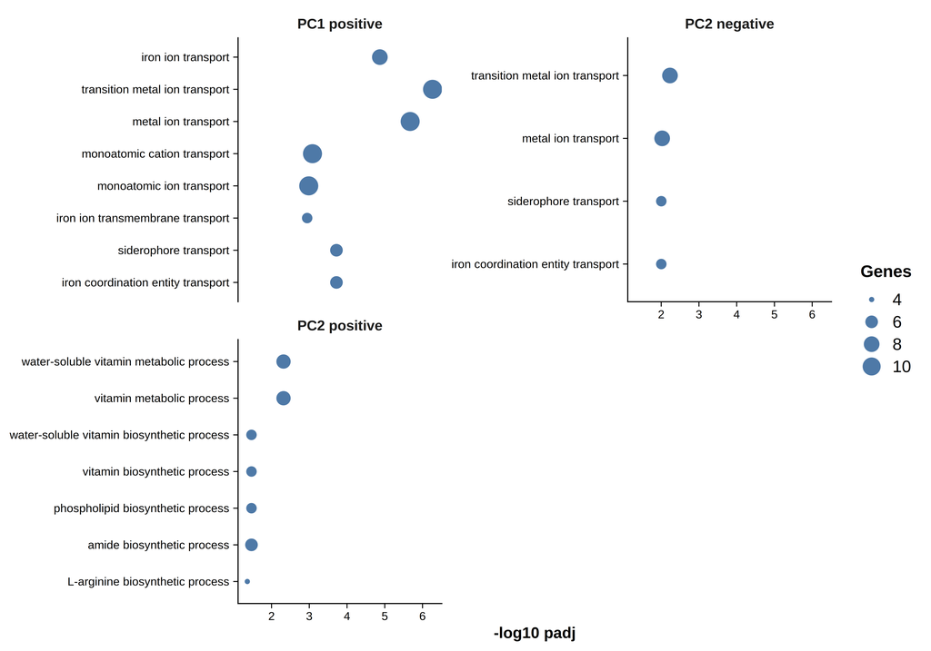

```r
# Only report / plot if at least one term is enriched
if (nrow(pc_go) > 0) {
  # Top 8 terms (smallest adjusted p) per pole
  knitr::kable(pc_go %>% group_by(gene_list) %>% slice_min(p.adjust, n = 8, with_ties = FALSE) %>%
                 select(gene_list, Description, GeneRatio, BgRatio, p.adjust),
               digits = 4, caption = "Top GO BP terms per PC pole")

  # Dot plot: one panel per pole, x = significance, dot size = number of genes
  p_pc_go <- pc_go %>%
    group_by(gene_list) %>% slice_min(p.adjust, n = 8, with_ties = FALSE) %>% ungroup() %>%
    mutate(Description = str_trunc(Description, 50)) %>%
    ggplot(aes(x = -log10(p.adjust), y = reorder(Description, -log10(p.adjust)), size = Count)) +
    geom_point(color = "#4E79A7") +
    facet_wrap(~ gene_list, scales = "free_y", ncol = 2) +
    labs(x = "-log10 padj", y = NULL, size = "Genes") +
    pub_theme +
    theme(axis.text = element_text(size = 9), axis.title = element_text(size = 12),
          strip.background = element_blank(), strip.text = element_text(size = 11, face = "bold"))
  print(p_pc_go)

  # Save the dot plot and the full enrichment table
  ggsave(file.path(OUT_DIR, "Fig1C_PC_loading_GO.pdf"), p_pc_go,
         width = 10, height = 7, units = "in", device = cairo_pdf)
  write.csv(pc_go, file.path(OUT_DIR, "Fig1C_PC_loading_GO.csv"), row.names = FALSE)
}
```

# Parameter sensitivity

The analysis parameters (`MIN_FRAC`, `N_TOP_GENES`, `N_PCS_SIL`) are conventional defaults (e.g. DESeq2 `plotPCA` uses the top 500 genes), not values tuned on this data. Here the PCA / PERMANOVA / silhouette are re-run over a grid of values: if conditions separate strongly across the whole grid, the conclusion does not depend on the parameter choice.

All three analyses are tested: replicate 1, replicate 2 (each with both fluconazole doses) and all datasets (four conditions, the two doses kept separate).

```r
# Values to test (the defaults used above are 0.25, 500 and 10)
SENS_MIN_FRAC <- c(0.10, 0.25, 0.50)
SENS_N_TOP    <- c(250, 500, 1000, 2000, Inf)   # Inf = all genes passing the filter
SENS_N_PCS    <- c(2, 5, 10, 20)

sens_sets <- list(
  "Replicate 1"          = c("YPD.1", "Flu.1", "Flu.2", "sc2glu.1"),
  "Replicate 2"          = c("YPD.2", "Flu.1", "Flu.2", "sc2glu.2"),
  "All datasets"         = names(raw)
)

# Every combination of analysis x expression filter x number of genes (3 x 3 x 5 = 45 runs)
sens_grid <- expand_grid(analysis = names(sens_sets),
                         min_frac = SENS_MIN_FRAC,
                         n_top    = SENS_N_TOP)

sens_results <- pmap_dfr(sens_grid, function(analysis, min_frac, n_top) {
  # run the same pipeline as above, hiding its printed output
  invisible(capture.output(suppressMessages(
    res <- condition_pca(sens_sets[[analysis]], analysis,
                         min_frac = min_frac, n_top = n_top)
  )))
  # silhouette for each number of PCs, from the same PCA
  pcs <- prcomp(res$x, center = TRUE, scale. = FALSE)$x
  sil <- map_dbl(SENS_N_PCS, function(k) {
    s <- silhouette(as.integer(res$meta$condition),
                    dist(pcs[, seq_len(min(k, ncol(pcs))), drop = FALSE]))
    mean(s[, "sil_width"])
  })
  tibble(analysis, min_frac, n_top,
         n_genes      = res$stats$n_genes,
         PC1_pct      = res$stats$PC1_pct,
         permanova_R2 = res$stats$permanova_R2,
         permanova_p  = res$stats$permanova_p,
         n_pcs_sil    = SENS_N_PCS,
         silhouette   = sil)
}) %>%
  mutate(n_top_label = factor(ifelse(is.infinite(n_top), "all", as.character(n_top)),
                              levels = c(as.character(SENS_N_TOP[is.finite(SENS_N_TOP)]), "all")),
         min_frac    = factor(min_frac))

# Range of each statistic per set over the whole grid
knitr::kable(
  sens_results %>% group_by(analysis) %>%
    summarise(R2_min  = min(permanova_R2), R2_max  = max(permanova_R2),
              p_max   = max(permanova_p),
              sil_min = min(silhouette),   sil_max = max(silhouette),
              .groups = "drop"),
  digits = 3, caption = "Range of PERMANOVA R2 and silhouette across all parameter values"
)
```

Range of PERMANOVA R2 and silhouette across all parameter values

| analysis | R2_min | R2_max | p_max | sil_min | sil_max |
| --- | --- | --- | --- | --- | --- |
| All datasets | 0.206 | 0.528 | 0.001 | 0.069 | 0.427 |
| Replicate 1 | 0.169 | 0.541 | 0.001 | 0.037 | 0.483 |
| Replicate 2 | 0.291 | 0.559 | 0.001 | 0.305 | 0.545 |

```r
# PERMANOVA R2 vs number of genes, one line per expression filter
# (R2 does not depend on the number of PCs, so one row per run is used)
p_sens_r2 <- sens_results %>%
  distinct(analysis, min_frac, n_top_label, permanova_R2) %>%
  ggplot(aes(n_top_label, permanova_R2, color = min_frac, group = min_frac)) +
  geom_line() + geom_point(size = 2) +
  facet_wrap(~ analysis) +
  scale_y_continuous(limits = c(0, 1)) +
  labs(x = "Most variable genes used", y = "PERMANOVA R2 (condition)",
       color = "Min. fraction\nof samples") +
  pub_theme

# Silhouette vs number of PCs at the default expression filter, one line per gene number
p_sens_sil <- sens_results %>%
  filter(min_frac == MIN_FRAC) %>%
  ggplot(aes(n_pcs_sil, silhouette, color = n_top_label, group = n_top_label)) +
  geom_line() + geom_point(size = 2) +
  facet_wrap(~ analysis) +
  scale_x_continuous(breaks = SENS_N_PCS) +
  scale_y_continuous(limits = c(-0.1, 1)) +
  labs(x = "PCs used for silhouette", y = "Mean silhouette (condition)",
       color = "Genes used") +
  pub_theme

p_sens <- p_sens_r2 / p_sens_sil
p_sens
```

[figure not shown]

```r
save_plot(p_sens_r2,  "Fig1C_parameter_sensitivity_R2",         width = 15, height = 4.5)
save_plot(p_sens_sil, "Fig1C_parameter_sensitivity_silhouette", width = 15, height = 4.5)
ggsave(file.path(OUT_DIR, "Fig1C_parameter_sensitivity.pdf"), p_sens,
       width = 15, height = 9, units = "in", device = cairo_pdf)
write.csv(sens_results %>% select(-n_top_label),
          file.path(OUT_DIR, "Fig1C_parameter_sensitivity.csv"), row.names = FALSE)
```